# Resume

### Utkal Sirikonda

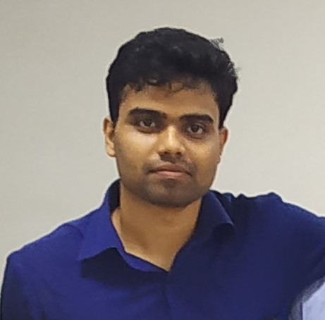

- **Phone:** (864) 765-8134
- **Email:** utkal082797@gmail.com
- **LinkedIn:** utkalsirikonda
- **GitHub:** Utkal97

## Experience

#### Software Engineer *(Jan 2025 – Present)*

##### **Tabbi Inc.** - Greenville, SC, USAs

- Developed and maintained a user-centric mobile application using **React Native** and **TypeScript**, enhancing performance and user experience.
- Optimized data retrieval by reorganizing and structuring files in **AWS S3**, reducing fetch latency and improving storage efficiency.
- Configured and automated **AWS Amplify policies** within a **CloudFormation stack**, streamlining infrastructure management and security compliance.
- Migrated **RESTful APIs** from **Ruby on Rails** to **Node.js**, integrating **GraphQL** for efficient data fetching and improved scalability.

#### Full-stack Developer Co-op *(June 2024 – Dec 2024)*

##### **SS&C Technologies** - Boston, MA, USA

- Developed a **Full-stack application** to visualize server health and test runs using **React, JavaScript, HTML, CSS**, and **Module Federation**.
- Decoupled a **monolith application** into **Node.js micro-services** with **PostgreSQL** and **Postman** testing. Containerized with **Docker**.
- Automated **OpenAPI Specification (OAS 3.0)** generation for **Resourceful REST APIs**.
- Implemented **Server Sent Events (SSE)** for live data charts, reducing client API calls by **70%**.

#### Technical Lead - Full-stack *(Jan 2021 – Aug 2023)*

##### **Inncircles** - Hyderabad, India

- Enhanced and sustained an internal construction management application using **Node.js, Express.js, React, and MongoDB**.
- Improved system performance by redesigning data models, reducing API runtime from **400ms to 80ms**.
- Implemented Redis caching, reducing response time to one-tenth.
- Managed a team of **4 software developers**, gathering functional requirements from clients.
- Developed an auto-scheduling algorithm analyzing **1.3M data points**, estimating project completion timelines.
- Automated work orders, material procurement, and data analysis involving **1M+ data points**.
- Replaced local file storage with **AWS S3** for managing visual work logs.

## Education

#### **Clemson University** *(Aug 2023 - May 2025)*

Master of Science in Computer Science  
**GPA:** *3.85/4.0*

#### **Indian Institute of Information Technology** *(Sep 2015 - Jun 2019)*

Bachelor of Technology in Computer Science  
**CGPA:** *8.3/10.0*

## Technical Skills

- **Languages:** Python, JavaScript/TypeScript
- **Technologies:** Node.js, Express.js, Django, React, Redux
- **Database:** MongoDB (NoSQL), TimeScaleDB (PostgreSQL)
- **Tools:** Git, Docker, AWS - S3, EC2, Lambda, DynamoDB, Amplify, CloudFormation
- **Coursework:**
  - Data Structures and Algorithms
  - Software Design
  - Object-Oriented Programming

## Projects

### Festive Fusion *(Python, Pygame)*

- Developed a **multi-level game** using **Python and Pygame**, implementing **Software Design Patterns**.
- Implemented key features like:
  - **Game save/load functionality** using the **Memento pattern**.
  - **Singleton and Factory patterns** for optimized object creation.

## R Code Demo

### R Code with Displayed Output

```r
project_description <- "Developed an adventure game using Python and Pygame, implementing Software Design Patterns"

print(project_description)
```

```
## [1] "Developed an adventure game using Python and Pygame, implementing Software Design Patterns"
```

### R Code with Hidden Code but Displayed Output

```
## [1] "I'm an experienced application developer and a graduate student at Clemson University. I'm graduating in May 2025 and looking for Software Development roles starting May 2025."
```